# Apps

One of my main goals as a statistics professor is to make statistics understandable, intuitive and even enjoyable. I am a big believer in the power of visualization, so I have built interactive Shiny apps that let students explore statistical concepts in a dynamic way. By manipulating different parameters and seeing the results firsthand, my hope for my students is that they develop a much deeper understanding that sticks with them.

### 📊️ One-Sample t-Test

Date: January 27, 2025

Explore and visualize how degrees of freedom and p-values affect the shape of the t-distribution and the critical regions. Choose your test type and hit “Generate Plot” to see it in action.

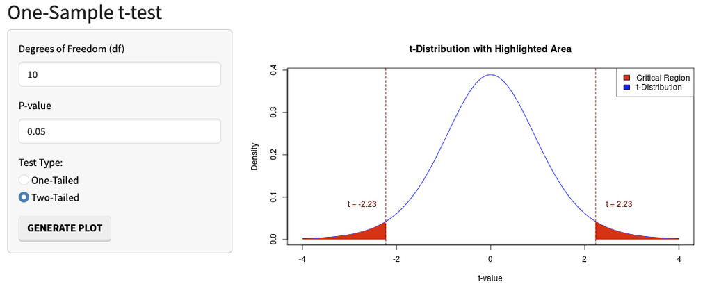

### 🔬️ Two-Sample t-Test

Date: January 20, 2025

Master Two-Sample t-Tests! This interactive visualization makes it easy to understand the core concepts. Manipulate the parameters and see the impact on the distributions and the critical region.

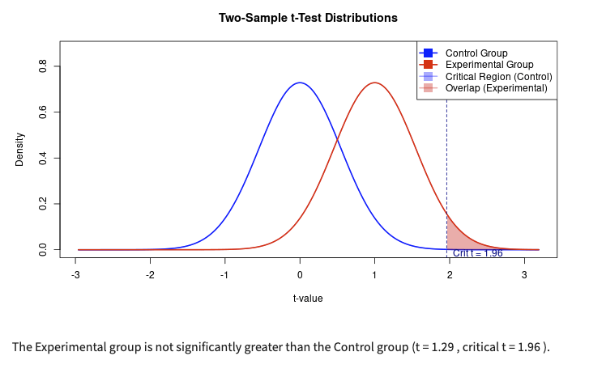

### 🧮️ Probabilty with Z-scores

Date: January 7, 2025

This app lets you visualize the probability between two z-scores in a standard normal distribution. 📈 Just enter the lower and upper z-scores, and see the shaded area representing the probability. Click “Calculate Probability” to get the answer!

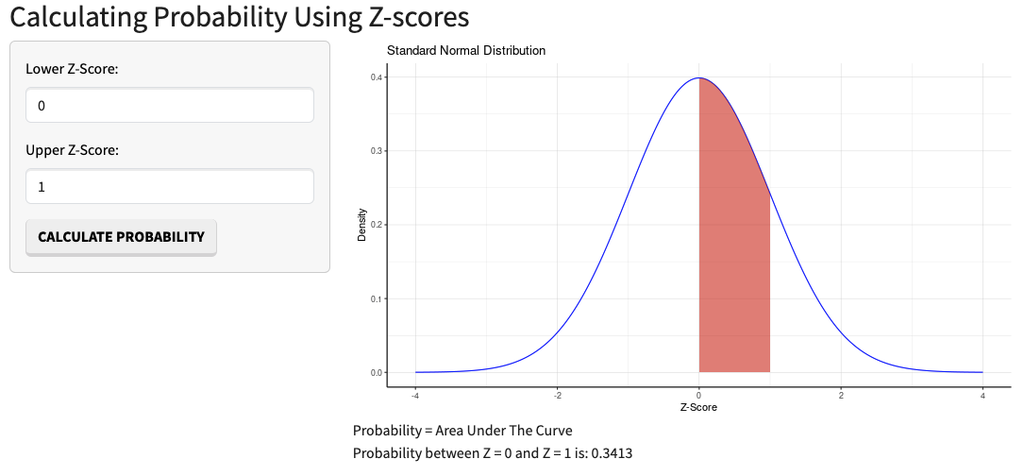

### ⚙️️ Explore Normal Distribution

Date: December 20, 2024

Visualize how changing the mean, standard deviation, and applying transformations (addition/subtraction and multiplication/division to each data point) affects the distribution of a simulated dataset.

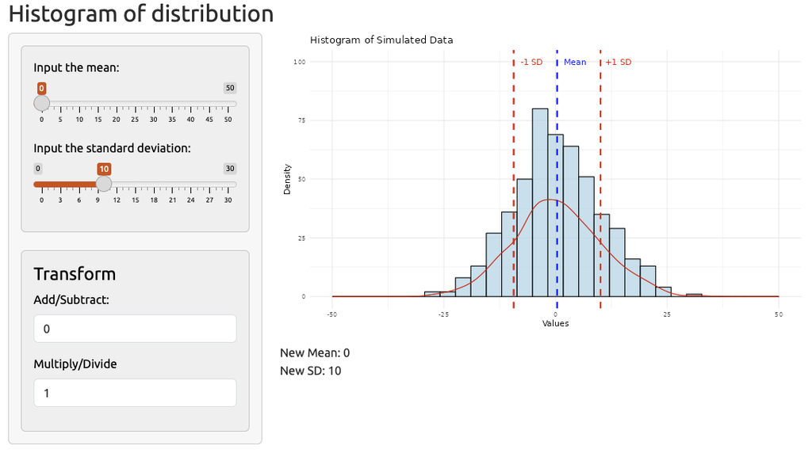

### ️️🗓️ StrikeThrough: Command-Line To-Do List

Date: January 26, 2025

For my CS50 Programming with Python final project, I built StrikeThrough, a simple yet effective command-line to-do list application. Inspired by the satisfying act of crossing off completed tasks, StrikeThrough lets you add tasks with due dates, automatically sorting your list for optimal prioritization. You can even break down larger tasks into subtasks for finer-grained tracking. Completed items are visually marked with a strikethrough and moved to the bottom of the list, providing a clear sense of progress. You can download the app [here](https://drive.google.com/file/d/1g4HEN4KiCVQbSTHyaizIjz3xG9jtZE7b/view?usp=sharing). For a tutorial of the app, see this [video](https://youtu.be/s2uiXC0TM0I).

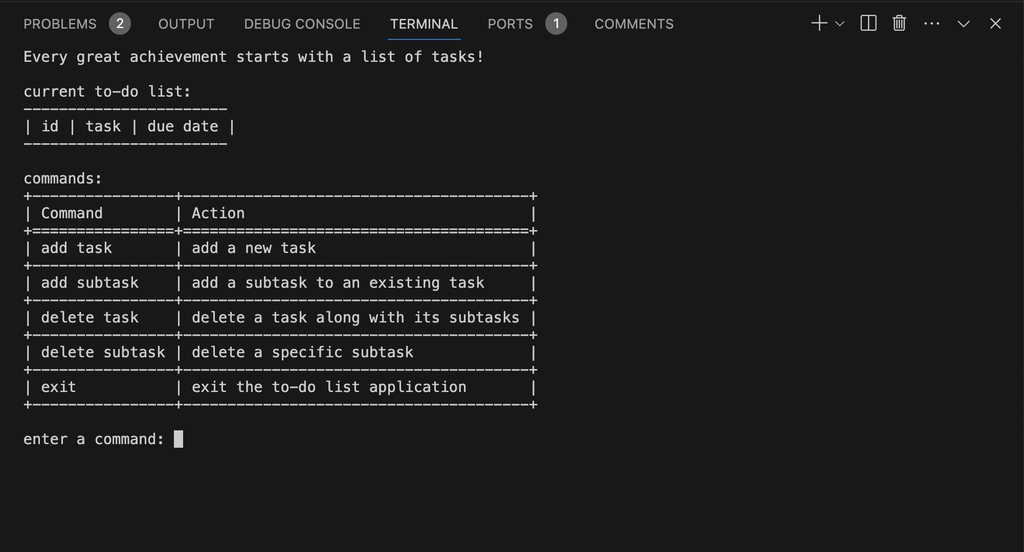

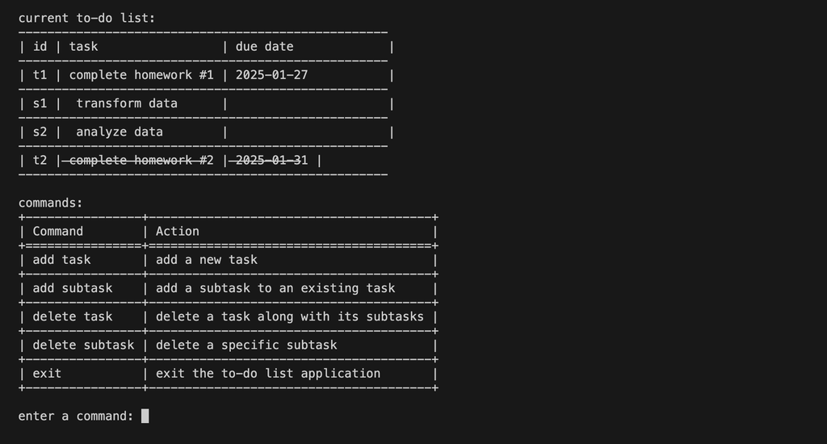